# R Introduction for Biology

Mark Dunning

Last modified: 02 Jan 2025

# Dealing with data

The [*tidyverse*](https://www.tidyverse.org/) is an eco-system of packages that provides a consistent, intuitive system for data manipulation and visualisation in R.

A spreadsheet that we would normally analyse in Excel can can be imported into R by using a *function* from the readr package.

- `read_csv`
- `read_tsv`

The readxl package can also import files in Excel’s own format

- `read_xls`
- `read_xlsx`

We will use the file `tcga_clinical_CLEANED.tsv` as an example. This file contains information about biological samples that were included as part of the TCGA (The Cancer Genome Atlas) project - all tumour types.

As the file name ends in `.tsv` the function we want is probably `read_tsv`

```r
library(readr)
clinical <- read_tsv("tcga_clinical_CLEANED.tsv")
```

If you got an error `could not find function "read_tsv"` at the previous step, it will because you don’t have the `readr` package loaded. The RStudio output may indicate some problems with the data, but we should be able to proceed.

If you get really stuck reading data into R, you can use the Import Dataset option from the File menu which will allow you to choose the parameters to read the data interactively

The Environment panel of RStudio (top-right) should show that an object called `clinical` has been created. This means that we can start doing analysis this dataset. The choice to call the object `clinical` was ours. We could have used any name instead of `clinical` but we chose something vaguely informative and memorable.

The dimensions of the object should should `7706 obs. of 420 variables`. This means the object we have created contains 7706 rows and 420 columns. Each row is a different observation; in this case a different biological sample. Each column records the value of a different variable. In R’s terminology, we have just created a `tibble` which is a special case of something called a `data.frame`. As we will see the the object can contain either numbers or text in each column.

RStudio has a browsing functionality available that we can activate using the `View` function

```r
View(clinical)
```

Observations that are missing are indicated by an `NA`. It may look at first glance that the table mostly contains missing data. This is because some columns are only recorded for particular tumour types and not all tumour types recorded the same information.

# Data Exploration

We will now start to explore the data with a couple of different questions in mind:-

- **What are the differences in male/female split between different tumour types?**
- **Is there a difference in diagnosis age in different tumour types?**

The tasks required to do this will be greatly helped by the `dplyr` package.

```r
library(dplyr)
```

## Choosing what columns to analyse

The `select` function allows us to narrow down the number of variables we are interested in from 420. The first argument is always the name of the data frame. There are numerous different ways of specifying which column(s) you want, including listing the names of the columns of interest. Let’s assume we already know the names of columns containing tumour type and gender.

```r
##Note that the spelling of "tumor" has to exactly match that found in the data
select(clinical,
       tumor_tissue_site,
       gender
       )
```

| tumor_tissue_site | gender |
| --- | --- |
| Brain | MALE |
| Brain | FEMALE |
| Brain | MALE |
| Brain | MALE |
| Brain | MALE |
| Ovary | FEMALE |
| Ovary | FEMALE |
| Ovary | FEMALE |
| Ovary | FEMALE |
| Ovary | FEMALE |

[output cut: 990 more lines]

We can reasonably guess that the Age information would be contained in a column that has “age” somewhere in the name. However, the column is not just called “age” or “Age”

```r
select(clinical, age)
select(clinical, Age)
```

Without manually going through the columns, there are a few “helper” functions that we can employ

```r
select(clinical, starts_with("age"))
```

| age_at_diagnosis | age_at_diagnosis.1 | age_at_initial_pathologic_diagnosis |
| --- | --- | --- |
| NA | NA | 78 |
| NA | NA | 62 |
| NA | NA | 43 |
| NA | NA | 53 |
| NA | NA | 64 |
| NA | NA | 70 |
| NA | NA | 78 |
| NA | NA | 78 |
| NA | NA | 85 |
| NA | NA | 72 |

[output cut: 990 more lines]

```r
select(clinical, contains("age"))
```

| tobacco_smoking_age_started | age_at_diagnosis | age_at_diagnosis.1 | ajcc_pathologic_tumor_stage | clinical_stage | age_at_initial_pathologic_diagnosis | history_exposure_leukemogenic_agents | cyto_and_immuno_test_percentage | allergy_food_dx_age | allergy_animals_insects_dx_age | ajcc_clinical_tumor_stage | jewish_religion_heritage_indicator | pathologic_stage |
| --- | --- | --- | --- | --- | --- | --- | --- | --- | --- | --- | --- | --- |
| NA | NA | NA | NA | NA | 78 | NA | NA | NA | NA | NA | NA | NA |
| NA | NA | NA | NA | NA | 62 | NA | NA | NA | NA | NA | NA | NA |
| NA | NA | NA | NA | NA | 43 | NA | NA | NA | NA | NA | NA | NA |
| NA | NA | NA | NA | NA | 53 | NA | NA | NA | NA | NA | NA | NA |
| NA | NA | NA | NA | NA | 64 | NA | NA | NA | NA | NA | NA | NA |
| NA | NA | NA | NA | Stage IIIC | 70 | NA | NA | NA | NA | NA | NA | NA |
| NA | NA | NA | NA | Stage IIIC | 78 | NA | NA | NA | NA | NA | NA | NA |
| NA | NA | NA | NA | Stage IIIC | 78 | NA | NA | NA | NA | NA | NA | NA |
| NA | NA | NA | NA | NA | 85 | NA | NA | NA | NA | NA | NA | NA |
| NA | NA | NA | NA | Stage IV | 72 | NA | NA | NA | NA | NA | NA | NA |

[output cut: 990 more lines]

```r
select(clinical, contains("age_"))
```

| tobacco_smoking_age_started | age_at_diagnosis | age_at_diagnosis.1 | age_at_initial_pathologic_diagnosis | jewish_religion_heritage_indicator |
| --- | --- | --- | --- | --- |
| NA | NA | NA | 78 | NA |
| NA | NA | NA | 62 | NA |
| NA | NA | NA | 43 | NA |
| NA | NA | NA | 53 | NA |
| NA | NA | NA | 64 | NA |
| NA | NA | NA | 70 | NA |
| NA | NA | NA | 78 | NA |
| NA | NA | NA | 78 | NA |
| NA | NA | NA | 85 | NA |
| NA | NA | NA | 72 | NA |

[output cut: 990 more lines]

Up to now we have not changed the underlying dataset. `select` is showing what the dataset looks like with the specified subset. If we want to make permanent changes we can create a variable

```r
analysis_data <- select(clinical,
                        tumor_tissue_site,
                        gender,
                        age_at_diagnosis)
```

## Restricting rows

The function to choose or restrict to the rows we might be interested in is called `filter`. We have to write a short R command to choose the rows.

e.g. we want only the male samples. Notice that two “=” signs are required. If you try and use the function with a single “=” R will print a helpful hint.

```r
filter(analysis_data, gender == "MALE")
```

| tumor_tissue_site | gender | age_at_diagnosis |
| --- | --- | --- |
| Brain | MALE | NA |
| Brain | MALE | NA |
| Brain | MALE | NA |
| Brain | MALE | NA |
| Lung | MALE | NA |
| Lung | MALE | NA |
| Lung | MALE | NA |
| Lung | MALE | NA |
| Lung | MALE | NA |
| Lung | MALE | NA |

[output cut: 990 more lines]

and the females

```r
filter(analysis_data, gender == "FEMALE")
```

| tumor_tissue_site | gender | age_at_diagnosis |
| --- | --- | --- |
| Brain | FEMALE | NA |
| Ovary | FEMALE | NA |
| Ovary | FEMALE | NA |
| Ovary | FEMALE | NA |
| Ovary | FEMALE | NA |
| Ovary | FEMALE | NA |
| Ovary | FEMALE | NA |
| Ovary | FEMALE | NA |
| Ovary | FEMALE | NA |
| Ovary | FEMALE | NA |

[output cut: 990 more lines]

An equivalent, but somewhat unnecessary for this example, statement would be to ask for rows where the gender is **not equal** to `MALE`

```r
filter(analysis_data, gender != "MALE")
```

| tumor_tissue_site | gender | age_at_diagnosis |
| --- | --- | --- |
| Brain | FEMALE | NA |
| Ovary | FEMALE | NA |
| Ovary | FEMALE | NA |
| Ovary | FEMALE | NA |
| Ovary | FEMALE | NA |
| Ovary | FEMALE | NA |
| Ovary | FEMALE | NA |
| Ovary | FEMALE | NA |
| Ovary | FEMALE | NA |
| Ovary | FEMALE | NA |

[output cut: 990 more lines]

We can also restrict the data based on numeric columns by using `>`, `<` etc.

```r
filter(analysis_data, age_at_diagnosis > 80)
```

| tumor_tissue_site | gender | age_at_diagnosis |
| --- | --- | --- |
| Breast | FEMALE | 85 |
| Breast | FEMALE | 82 |
| Breast | FEMALE | 85 |
| Breast | FEMALE | 90 |
| Endometrial | FEMALE | 81 |
| Endometrial | FEMALE | 86 |
| Breast | FEMALE | 84 |
| Breast | FEMALE | 84 |
| Breast | FEMALE | 81 |
| Breast | FEMALE | 85 |

[output cut: 139 more lines]

But what if we want males with Brain tumours? `dplyr` allows us to combine more than one condition if we separate them with a `,`. In computing this is known as an “and” statement and only rows where **both** statements are two will be shown. The line could be extended to include more than two tests if we wanted to.

```r
filter(analysis_data, gender == "MALE",tumor_tissue_site == "Brain")
```

| tumor_tissue_site | gender | age_at_diagnosis |
| --- | --- | --- |
| Brain | MALE | NA |
| Brain | MALE | NA |
| Brain | MALE | NA |
| Brain | MALE | NA |
| Brain | MALE | NA |
| Brain | MALE | NA |
| Brain | MALE | NA |
| Brain | MALE | NA |
| Brain | MALE | NA |
| Brain | MALE | NA |

[output cut: 91 more lines]

Brain or Lung tumours? Using a `|` symbol instead of a `,` allows for *either* of two (or more) conditions to be `TRUE`.

```r
filter(analysis_data, tumor_tissue_site == "Brain" | tumor_tissue_site == "Lung")
```

| tumor_tissue_site | gender | age_at_diagnosis |
| --- | --- | --- |
| Brain | MALE | NA |
| Brain | FEMALE | NA |
| Brain | MALE | NA |
| Brain | MALE | NA |
| Brain | MALE | NA |
| Lung | MALE | NA |
| Lung | MALE | NA |
| Lung | FEMALE | NA |
| Lung | MALE | NA |
| Lung | MALE | NA |

[output cut: 990 more lines]

To answer the question of how many males / females have a certain tumour type we could now use R statements such as:-

```r
filter(analysis_data, gender == "MALE",tumor_tissue_site == "Brain")
```

| tumor_tissue_site | gender | age_at_diagnosis |
| --- | --- | --- |
| Brain | MALE | NA |
| Brain | MALE | NA |
| Brain | MALE | NA |
| Brain | MALE | NA |
| Brain | MALE | NA |
| Brain | MALE | NA |
| Brain | MALE | NA |
| Brain | MALE | NA |
| Brain | MALE | NA |
| Brain | MALE | NA |

[output cut: 91 more lines]

```r
filter(analysis_data, gender == "FEMALE",tumor_tissue_site == "Brain")
```

| tumor_tissue_site | gender | age_at_diagnosis |
| --- | --- | --- |
| Brain | FEMALE | NA |
| Brain | FEMALE | NA |
| Brain | FEMALE | NA |
| Brain | FEMALE | NA |
| Brain | FEMALE | NA |
| Brain | FEMALE | NA |
| Brain | FEMALE | NA |
| Brain | FEMALE | NA |
| Brain | FEMALE | NA |
| Brain | FEMALE | NA |

[output cut: 43 more lines]

```r
NA
```

and make a note of the number of observations included in the resulting data frame. Although useful for data exploration, it would clearly be inefficient to get gender/tumour type counts in this way as we would have to repeat for all combinations of tumour type and gender. The function `count` can now give us exactly what we want.

```r
count(analysis_data,
      tumor_tissue_site,
      gender)
```

| tumor_tissue_site | gender | n |
| --- | --- | --- |
| Bladder | FEMALE | 50 |
| Bladder | MALE | 163 |
| Bone Marrow | FEMALE | 73 |
| Bone Marrow | MALE | 90 |
| Brain | FEMALE | 53 |
| Brain | MALE | 101 |
| Breast | FEMALE | 983 |
| Breast | MALE | 11 |
| Central nervous system | FEMALE | 172 |
| Central nervous system | MALE | 223 |

[output cut: 24 more lines]

The `count` function is useful for tabulating the number of observations, but for other summary statistics a more general `sumamrise` function can be used. This can be used in conjunction with the basic summary statistics supported by base R. A summary statistic being something that can be applied to a series of numbers and produce a single number as a result. e.g. the average, minimum, maximum etc.

```r
summarise(analysis_data,
          Average = mean(age_at_diagnosis),
          min = min(age_at_diagnosis),
          max = max(age_at_diagnosis))
```

| Average | min | max |
| --- | --- | --- |
| NA | NA | NA |

However, we obviously have a problem due to missing values. If R sees and missing values in a column it will report the mean, minimum or maximum of that column as a missing value. Although this default behaviour can be changes, before proceeding we could also choose to remove any missing observations from the data. These are represented by a `NA` value, which is a special value and not a character label.

```r
filter(analysis_data, is.na(age_at_diagnosis) | is.na(tumor_tissue_site))
```

| tumor_tissue_site | gender | age_at_diagnosis |
| --- | --- | --- |
| Brain | MALE | NA |
| Brain | FEMALE | NA |
| Brain | MALE | NA |
| Brain | MALE | NA |
| Brain | MALE | NA |
| Ovary | FEMALE | NA |
| Ovary | FEMALE | NA |
| Ovary | FEMALE | NA |
| Ovary | FEMALE | NA |
| Ovary | FEMALE | NA |

[output cut: 990 more lines]

We want the opposite of the above; where the age of diagnosis and tumour site is **not** missing.

```r
analysis_data <- filter(analysis_data, !is.na(age_at_diagnosis), !is.na(tumor_tissue_site))
```

The summary will now work as expected.

```r
summarise(analysis_data,
          Average = mean(age_at_diagnosis),
          min = min(age_at_diagnosis),
          max = max(age_at_diagnosis))
```

| Average | min | max |
| --- | --- | --- |
| 58.15625 | 15 | 90 |

This might not be what we want in all circumstances, as the statistics can also be calculated on a per-tumour site basis.

```r
data_grouped <- group_by(analysis_data, tumor_tissue_site)
summarise(data_grouped,Average = mean(age_at_diagnosis),
          min = min(age_at_diagnosis),
          max = max(age_at_diagnosis) )
```

| tumor_tissue_site | Average | min | max |
| --- | --- | --- | --- |
| Bladder | 67.70755 | 34 | 90 |
| Bone Marrow | 55.46626 | 18 | 88 |
| Breast | 58.55533 | 26 | 90 |
| Endometrial | 63.69102 | 31 | 90 |
| Liver | 61.87952 | 20 | 88 |
| Thyroid | 47.25934 | 15 | 89 |

Further investigation of the data could also involve finding the observations with the maximum or minimum diagnosis age.

```r
## desc specifies descending order
arrange(analysis_data, desc(age_at_diagnosis))
```

| tumor_tissue_site | gender | age_at_diagnosis |
| --- | --- | --- |
| Breast | FEMALE | 90 |
| Breast | FEMALE | 90 |
| Breast | FEMALE | 90 |
| Endometrial | FEMALE | 90 |
| Endometrial | FEMALE | 90 |
| Breast | FEMALE | 90 |
| Breast | FEMALE | 90 |
| Breast | FEMALE | 90 |
| Endometrial | FEMALE | 90 |
| Breast | FEMALE | 90 |

[output cut: 990 more lines]

```r
arrange(analysis_data, tumor_tissue_site, desc(age_at_diagnosis))
```

| tumor_tissue_site | gender | age_at_diagnosis |
| --- | --- | --- |
| Bladder | FEMALE | 90 |
| Bladder | MALE | 87 |
| Bladder | MALE | 87 |
| Bladder | MALE | 86 |
| Bladder | MALE | 85 |
| Bladder | MALE | 85 |
| Bladder | MALE | 84 |
| Bladder | MALE | 84 |
| Bladder | FEMALE | 84 |
| Bladder | MALE | 84 |

[output cut: 990 more lines]

```r
## could also add another sorting variable of gender if we wanted!
```

So far we have used several operations in isolation. However, the real joy (?) of `dplyr` is how different operations can be chained together. Lets say we just wanted female tumours.

```r
filter(analysis_data, gender == "FEMALE")
```

| tumor_tissue_site | gender | age_at_diagnosis |
| --- | --- | --- |
| Breast | FEMALE | 70 |
| Breast | FEMALE | 59 |
| Breast | FEMALE | 56 |
| Breast | FEMALE | 54 |
| Breast | FEMALE | 61 |
| Breast | FEMALE | 39 |
| Breast | FEMALE | 52 |
| Breast | FEMALE | 39 |
| Breast | FEMALE | 54 |
| Breast | FEMALE | 50 |

[output cut: 990 more lines]

Our next step could be to remove the `gender` column since it is somewhat redundant.

```r
analysis_data2 <- filter(analysis_data, gender == "FEMALE")
select(analysis_data2, tumor_tissue_site, age_at_diagnosis)
```

| tumor_tissue_site | age_at_diagnosis |
| --- | --- |
| Breast | 70 |
| Breast | 59 |
| Breast | 56 |
| Breast | 54 |
| Breast | 61 |
| Breast | 39 |
| Breast | 52 |
| Breast | 39 |
| Breast | 54 |
| Breast | 50 |

[output cut: 990 more lines]

```r
## or
## select(analysis_data2, -gender)
```

The code would quickly get cumbersome if we wanted to include additional steps such as removing `NA` values. An alternative approach called “piping” is recommended.

```r
filter(analysis_data, gender == "FEMALE") %>% ## and then...
  select(tumor_tissue_site, age_at_diagnosis) ## %>% and then...
```

| tumor_tissue_site | age_at_diagnosis |
| --- | --- |
| Breast | 70 |
| Breast | 59 |
| Breast | 56 |
| Breast | 54 |
| Breast | 61 |
| Breast | 39 |
| Breast | 52 |
| Breast | 39 |
| Breast | 54 |
| Breast | 50 |

[output cut: 990 more lines]

## Overview of plotting

Our recommending way of creating plots in RStudio is to use the `ggplot2` package

```r
library(ggplot2)
```

A couple of useful references are given here-

- [ggplot2 reference guide](https://posit.co/wp-content/uploads/2022/10/data-visualization-1.pdf)
- [Flowchart for deciding on what graph type to use](https://www.data-to-viz.com/)

The general principle of creating a plot is the same regardless of what kind of plot we want to make

- specify the `data frame` containing the data we want to plot
- specify which columns in that data frame we want to use for various aesthetic aspects of the plot
- define the type of plot we want
- apply any additional format changes

In order to compare the age distributions of different tumour types we can imagine this being displayed as a boxplot with

- the age variable on the y-axis
- the type of tumour on the x-axis

this can be translated into `ggplot2` language as follows -

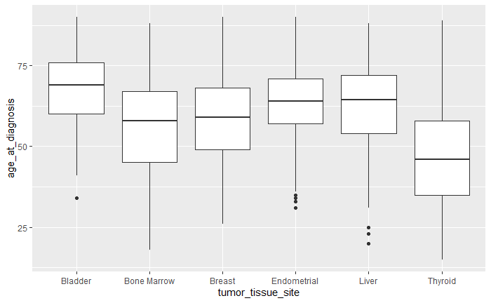

```r
ggplot(analysis_data, aes(x = tumor_tissue_site, y = age_at_diagnosis)) + geom_boxplot()
```

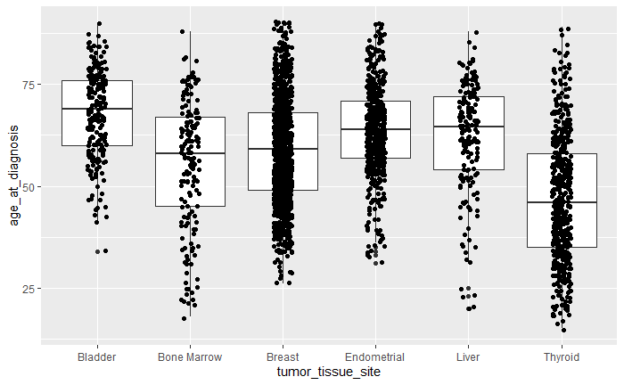

```r
ggplot(analysis_data, aes(x = tumor_tissue_site, y = age_at_diagnosis)) + geom_boxplot() + geom_jitter(width=0.1)
```

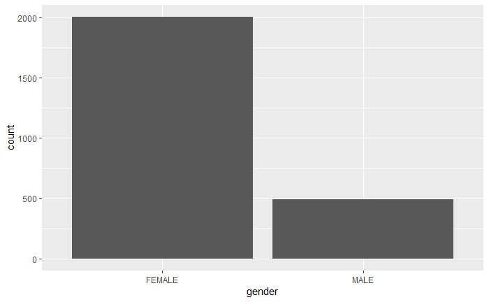

```r
ggplot(analysis_data, aes(x = gender)) + geom_bar()
```

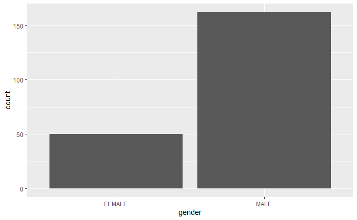

```r
bladder_data <- filter(analysis_data, tumor_tissue_site == "Bladder")
ggplot(bladder_data, aes(x = gender)) + geom_bar()
```

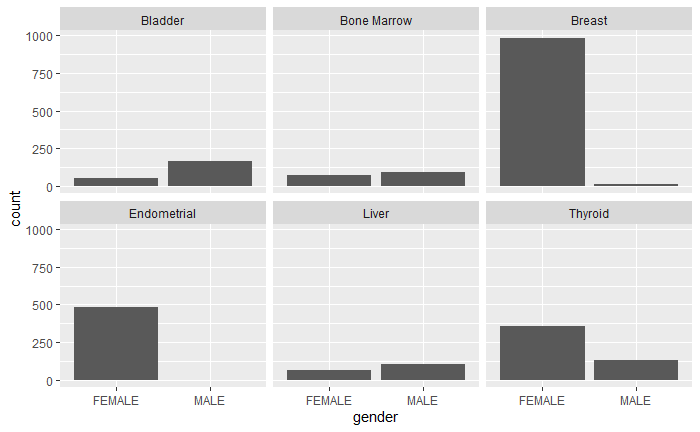

```r
ggplot(analysis_data, aes(x = gender)) + geom_bar() + facet_wrap(~tumor_tissue_site)
```